# Lab 1 Grading Guidelines

## Part 2. Matrices (7 points)

A Binomial distribution with $n$ trials and probability of success $p$, sometimes shorthanded $Bin(n, p)$, represents the number of success out of $n$ independent trials, each with probability of success $p$. For this part, we will be using the Binomial distribution equivalent of the functions we used in part 1. These are `rbinom()`, `pbinom()`, and `dbinom()`.

**2a.** Initialize two empty matrices. One should have 10 rows and 4 columns, the other should have 10,000 rows and 4 columns. Be sure to give them informative names that follow style guidelines.

**Any reasonable names should receive credit–even ones like those below.**

```r
small_mat <- matrix(NA, nrow = 10, ncol = 4)
big_mat <- matrix(NA, nrow = 10000, ncol = 4)
```

**2b.** Separately fill the first column of each matrix with independent draws from a Binomial distribution with probability $0.2$ and $n=5$. Repeat this process for the second through fourth columns using probabilities of $0.4$, $0.6$, and $0.8$, respectively. Print out the first five rows of each matrix.

**Any reasonable names should receive credit–even ones like those below.**

```r
# fill columns of small matrix
small_mat[, 1] <- rbinom(n = 10, size = 5, prob = .2)
small_mat[, 2] <- rbinom(n = 10, size = 5, prob = .4)
small_mat[, 3] <- rbinom(n = 10, size = 5, prob = .6)
small_mat[, 4] <- rbinom(n = 10, size = 5, prob = .8)

# fill columns of big matrix
big_mat[, 1] <- rbinom(n = 10000, size = 5, prob = .2)
big_mat[, 2] <- rbinom(n = 10000, size = 5, prob = .4)
big_mat[, 3] <- rbinom(n = 10000, size = 5, prob = .6)
big_mat[, 4] <- rbinom(n = 10000, size = 5, prob = .8)

head(small_mat, n= 5)
```

```
##      [,1] [,2] [,3] [,4]
## [1,]    0    1    2    5
## [2,]    1    3    2    4
## [3,]    2    3    3    5
## [4,]    3    2    4    4
## [5,]    1    2    3    5
```

```r
head(big_mat, n= 5)
```

```
##      [,1] [,2] [,3] [,4]
## [1,]    1    1    3    3
## [2,]    2    4    3    1
## [3,]    2    2    5    3
## [4,]    0    2    4    5
## [5,]    0    2    3    4
```

**2c.** Use four well-labeled histograms to plot the values of each column. Set the `breaks` parameter to a reasonable integer value for these data. Discuss what you see.

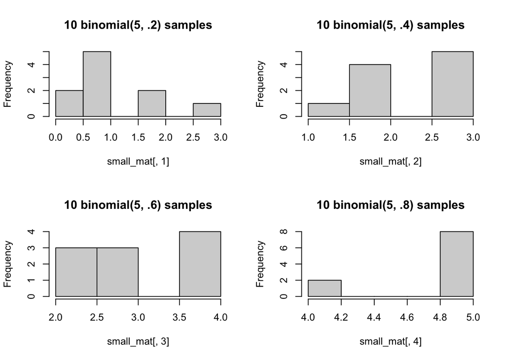

```r
par(mfrow = c(2, 2)) # formats plots into 2x2 grid; not necessary for students to do this.
hist(small_mat[, 1], main = "10 binomial(5, .2) samples", breaks = 6)
hist(small_mat[, 2], main = "10 binomial(5, .4) samples", breaks = 6)
hist(small_mat[, 3], main = "10 binomial(5, .6) samples", breaks = 6)
hist(small_mat[, 4], main = "10 binomial(5, .8) samples", breaks = 6)
```

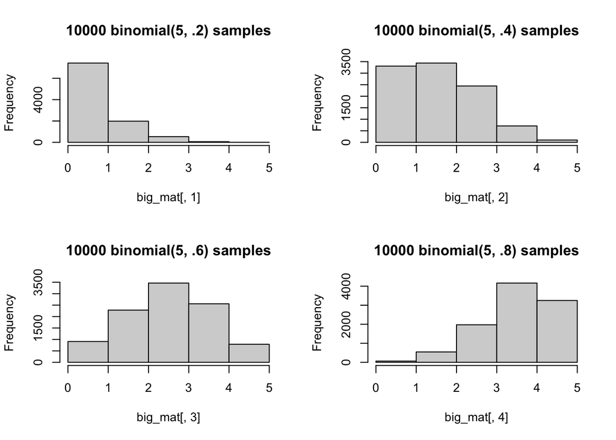

```r
par(mfrow = c(2, 2)) # formats plots into 2x2 grid; not necessary for students to do this.
hist(big_mat[, 1], main = "10000 binomial(5, .2) samples", breaks = 6)
hist(big_mat[, 2], main = "10000 binomial(5, .4) samples", breaks = 6)
hist(big_mat[, 3], main = "10000 binomial(5, .6) samples", breaks = 6)
hist(big_mat[, 4], main = "10000 binomial(5, .8) samples", breaks = 6)
```

**Any reasonable description should receive credit.**

**2d.** Calculate the column means of both matrices and present these results in a single table. The rows and columns of your tables should be easy to read and interpret.

```r
colmeans_df <- data.frame(p = c(.2, .4, .6, .8),
                          mat_10 = colMeans(small_mat),
                          mat_10000 = colMeans(big_mat))
knitr::kable(colmeans_df)
```

| p | mat_10 | mat_10000 |
| --- | --- | --- |
| 0.2 | 1.2 | 0.9946 |
| 0.4 | 2.4 | 2.0104 |
| 0.6 | 3.1 | 2.9917 |
| 0.8 | 4.8 | 3.9980 |

**Table doesn’t have to be fancy, but students should make some effort.**

**2e.** What is the *expected* column mean for each column? Which matrix has observed column means that are closer to this expectation? Why do you think that is?

**2f.** What is the theoretical variance for the values in each column? Which matrix has observed column sample variances that are closer to this value? Why do you think that is?